# Gov 50 Final Project

Linda

2022-12-14

## Cleaning up data

```r
library(tidyverse)
wvs <- read_csv("WVS_Cross-National_Wave_7_csv_v4_0.csv")
wvs
```

```
## # A tibble: 87,822 × 552
##    version   doi   A_WAVE A_YEAR A_STUDY B_COU…¹ B_COU…² C_COW…³ C_COW…⁴ D_INT…⁵
##    <chr>     <chr>  <dbl>  <dbl>   <dbl>   <dbl> <chr>     <dbl> <chr>     <dbl>
##  1 4-0-0 (2… doi.…      7   2019       2     196 CYP         352 CYP      1.96e8
##  2 4-0-0 (2… doi.…      7   2019       2     196 CYP         352 CYP      1.96e8
##  3 4-0-0 (2… doi.…      7   2019       2     196 CYP         352 CYP      1.96e8
##  4 4-0-0 (2… doi.…      7   2019       2     196 CYP         352 CYP      1.96e8
##  5 4-0-0 (2… doi.…      7   2019       2     196 CYP         352 CYP      1.96e8
##  6 4-0-0 (2… doi.…      7   2019       2     196 CYP         352 CYP      1.96e8
##  7 4-0-0 (2… doi.…      7   2019       2     196 CYP         352 CYP      1.96e8
##  8 4-0-0 (2… doi.…      7   2019       2     196 CYP         352 CYP      1.96e8
##  9 4-0-0 (2… doi.…      7   2019       2     196 CYP         352 CYP      1.96e8
## 10 4-0-0 (2… doi.…      7   2019       2     196 CYP         352 CYP      1.96e8
## # … with 87,812 more rows, 542 more variables: J_INTDATE <dbl>, FW_START <dbl>,
## #   FW_END <dbl>, K_TIME_START <dbl>, K_TIME_END <dbl>, K_DURATION <dbl>,
## #   Q_MODE <dbl>, N_REGION_ISO <dbl>, N_REGION_WVS <dbl>, N_TOWN <dbl>,
## #   G_TOWNSIZE <dbl>, G_TOWNSIZE2 <dbl>, H_SETTLEMENT <dbl>, H_URBRURAL <dbl>,
## #   I_PSU <dbl>, O1_LONGITUDE <dbl>, O2_LATITUDE <dbl>,
## #   L_INTERVIEWER_NUMBER <dbl>, S_INTLANGUAGE <dbl>, LNGE_ISO <chr>,
## #   E_RESPINT <dbl>, F_INTPRIVACY <dbl>, E1_LITERACY <dbl>, W_WEIGHT <dbl>, …
```

```r
wvs1 <- wvs |>
  select(A_YEAR, A_STUDY, B_COUNTRY, B_COUNTRY_ALPHA, D_INTERVIEW, L_INTERVIEWER_NUMBER, Q275, Q288, Q199:Q212)
wvs1
```

```
## # A tibble: 87,822 × 22
##    A_YEAR A_STUDY B_COUN…¹ B_COU…² D_INT…³ L_INT…⁴  Q275  Q288  Q199  Q200  Q201
##     <dbl>   <dbl>    <dbl> <chr>     <dbl>   <dbl> <dbl> <dbl> <dbl> <dbl> <dbl>
##  1   2019       2      196 CYP      1.96e8     633     1     5     4     3     5
##  2   2019       2      196 CYP      1.96e8     633     1     5     3     3     1
##  3   2019       2      196 CYP      1.96e8     633     4     3     3     2     2
##  4   2019       2      196 CYP      1.96e8     633     3     5     3     3     5
##  5   2019       2      196 CYP      1.96e8     633     3     3     4     3     5
##  6   2019       2      196 CYP      1.96e8     633     3     5     4     2     5
##  7   2019       2      196 CYP      1.96e8     633     2     3     4     2     5
##  8   2019       2      196 CYP      1.96e8     633     3     5     4     3     5
##  9   2019       2      196 CYP      1.96e8     633     1     7     4     2     5
## 10   2019       2      196 CYP      1.96e8     633     0     3     4     3     5
## # … with 87,812 more rows, 11 more variables: Q202 <dbl>, Q203 <dbl>,
## #   Q204 <dbl>, Q205 <dbl>, Q206 <dbl>, Q207 <dbl>, Q208 <dbl>, Q209 <dbl>,
## #   Q210 <dbl>, Q211 <dbl>, Q212 <dbl>, and abbreviated variable names
## #   ¹B_COUNTRY, ²B_COUNTRY_ALPHA, ³D_INTERVIEW, ⁴L_INTERVIEWER_NUMBER
```

```r
wvs2 <- wvs1 |>
  rename(education = Q275,
         income = Q288,
         political_interest = Q199,
         discuss_w_friends = Q200,
         newspaper = Q201,
         tv = Q202,
         radio = Q203,
         phone = Q204,
         email = Q205,
         internet = Q206,
         social_media = Q207,
         informal_talks = Q208,
         petition = Q209,
         boycotts = Q210,
         demonstrations = Q211,
         strikes = Q212)
wvs2
```

```
## # A tibble: 87,822 × 22
##    A_YEAR A_STUDY B_COU…¹ B_COU…² D_INT…³ L_INT…⁴ educa…⁵ income polit…⁶ discu…⁷
##     <dbl>   <dbl>   <dbl> <chr>     <dbl>   <dbl>   <dbl>  <dbl>   <dbl>   <dbl>
##  1   2019       2     196 CYP      1.96e8     633       1      5       4       3
##  2   2019       2     196 CYP      1.96e8     633       1      5       3       3
##  3   2019       2     196 CYP      1.96e8     633       4      3       3       2
##  4   2019       2     196 CYP      1.96e8     633       3      5       3       3
##  5   2019       2     196 CYP      1.96e8     633       3      3       4       3
##  6   2019       2     196 CYP      1.96e8     633       3      5       4       2
##  7   2019       2     196 CYP      1.96e8     633       2      3       4       2
##  8   2019       2     196 CYP      1.96e8     633       3      5       4       3
##  9   2019       2     196 CYP      1.96e8     633       1      7       4       2
## 10   2019       2     196 CYP      1.96e8     633       0      3       4       3
## # … with 87,812 more rows, 12 more variables: newspaper <dbl>, tv <dbl>,
## #   radio <dbl>, phone <dbl>, email <dbl>, internet <dbl>, social_media <dbl>,
## #   informal_talks <dbl>, petition <dbl>, boycotts <dbl>, demonstrations <dbl>,
## #   strikes <dbl>, and abbreviated variable names ¹B_COUNTRY, ²B_COUNTRY_ALPHA,
## #   ³D_INTERVIEW, ⁴L_INTERVIEWER_NUMBER, ⁵education, ⁶political_interest,
## #   ⁷discuss_w_friends
```

```r
library(countrycode)
wvs3 <- wvs2 |>
  mutate(Country = countrycode(B_COUNTRY_ALPHA, origin = "iso3c", destination = "country.name")) |>
  select(!c(B_COUNTRY, B_COUNTRY_ALPHA))
wvs3
```

```
## # A tibble: 87,822 × 21
##    A_YEAR A_STUDY D_INTER…¹ L_INT…² educa…³ income polit…⁴ discu…⁵ newsp…⁶    tv
##     <dbl>   <dbl>     <dbl>   <dbl>   <dbl>  <dbl>   <dbl>   <dbl>   <dbl> <dbl>
##  1   2019       2 196070011     633       1      5       4       3       5     1
##  2   2019       2 196070036     633       1      5       3       3       1     1
##  3   2019       2 196070039     633       4      3       3       2       2     1
##  4   2019       2 196070040     633       3      5       3       3       5     1
##  5   2019       2 196070053     633       3      3       4       3       5     1
##  6   2019       2 196070058     633       3      5       4       2       5     1
##  7   2019       2 196070067     633       2      3       4       2       5     1
##  8   2019       2 196070069     633       3      5       4       3       5     1
##  9   2019       2 196070070     633       1      7       4       2       5     1
## 10   2019       2 196070074     633       0      3       4       3       5     1
## # … with 87,812 more rows, 11 more variables: radio <dbl>, phone <dbl>,
## #   email <dbl>, internet <dbl>, social_media <dbl>, informal_talks <dbl>,
## #   petition <dbl>, boycotts <dbl>, demonstrations <dbl>, strikes <dbl>,
## #   Country <chr>, and abbreviated variable names ¹D_INTERVIEW,
## #   ²L_INTERVIEWER_NUMBER, ³education, ⁴political_interest, ⁵discuss_w_friends,
## #   ⁶newspaper
```

```r
wvs_data <- wvs3 |>
  group_by(Country) |>
  summarize(education = mean(education, na.rm = TRUE) / 8,
         income = mean(income, na.rm = TRUE) / 10,
         political_interest = (4 - mean(political_interest, na.rm = TRUE)) / 4,
         discuss_w_friends = (3 - mean(discuss_w_friends, na.rm = TRUE)) / 3,
         newspaper = (5 - mean(newspaper, na.rm = TRUE)) / 5,
         tv = (5 - mean(tv, na.rm = TRUE)) / 5,
         radio = (5 - mean(radio, na.rm = TRUE)) / 5,
         phone = (5 - mean(phone, na.rm = TRUE)) / 5,
         email = (5 - mean(email, na.rm = TRUE)) / 5,
         internet = (5 - mean(internet, na.rm = TRUE)) / 5,
         social_media = (5 - mean(social_media, na.rm = TRUE)) / 5,
         informal_talks = (5 - mean(informal_talks, na.rm = TRUE)) / 5,
         petition = (3 - mean(petition, na.rm = TRUE)) / 3,
         boycotts = (3 - mean(boycotts, na.rm = TRUE)) / 3,
         demonstrations = (3 - mean(demonstrations, na.rm = TRUE)) / 3,
         strikes = (3 - mean(strikes, na.rm = TRUE)) / 3
            )
wvs_data
```

```
## # A tibble: 59 × 17
##    Country    education income politi…¹ discu…² newsp…³    tv radio phone  email
##    <chr>          <dbl>  <dbl>    <dbl>   <dbl>   <dbl> <dbl> <dbl> <dbl>  <dbl>
##  1 Andorra        0.482  0.536    0.330   0.277  0.632  0.644 0.358 0.497 0.359
##  2 Argentina      0.342  0.508    0.293   0.250  0.355  0.693 0.486 0.505 0.310
##  3 Armenia        0.555  0.470    0.387   0.422  0.0981 0.657 0.134 0.590 0.159
##  4 Australia      0.582  0.513    0.413   0.317  0.448  0.677 0.612 0.519 0.467
##  5 Bangladesh     0.232  0.562    0.258   0.219  0.259  0.690 0.129 0.449 0.0676
##  6 Bolivia        0.419  0.501    0.239   0.200  0.351  0.731 0.498 0.406 0.183
##  7 Brazil         0.347  0.402    0.276   0.237  0.309  0.656 0.340 0.532 0.275
##  8 Canada         0.612  0.557    0.432   0.325  0.370  0.554 0.488 0.549 0.508
##  9 Chile          0.478  0.468    0.234   0.184  0.410  0.674 0.476 0.520 0.403
## 10 China          0.354  0.415    0.378   0.241  0.165  0.620 0.180 0.621 0.173
## # … with 49 more rows, 7 more variables: internet <dbl>, social_media <dbl>,
## #   informal_talks <dbl>, petition <dbl>, boycotts <dbl>, demonstrations <dbl>,
## #   strikes <dbl>, and abbreviated variable names ¹political_interest,
## #   ²discuss_w_friends, ³newspaper
```

```r
freedom_house <- read_csv("Freedom of the Press 2017.csv")
freedom_house <- freedom_house |>
  rename(total_score = "Total Score") |>
  mutate(total_score = as.integer(total_score)) |>
  group_by(Country) |>
  summarize(media_freedom_score = (100 - total_score) / 100
            )
freedom_house
```

```
## # A tibble: 210 × 2
##    Country             media_freedom_score
##    <chr>                             <dbl>
##  1 Afghanistan                        0.4
##  2 Albania                            0.49
##  3 Algeria                            0.35
##  4 Andorra                            0.85
##  5 Angola                             0.27
##  6 Antigua and Barbuda                0.66
##  7 Argentina                          0.54
##  8 Armenia                            0.37
##  9 Australia                          0.78
## 10 Austria                            0.78
## # … with 200 more rows
```

```r
freedom <- wvs_data |>
  inner_join(freedom_house) |>
  select(Country, media_freedom_score, education:strikes)
freedom
```

```
## # A tibble: 55 × 18
##    Country    media_f…¹ educa…² income polit…³ discu…⁴ newsp…⁵    tv radio phone
##    <chr>          <dbl>   <dbl>  <dbl>   <dbl>   <dbl>   <dbl> <dbl> <dbl> <dbl>
##  1 Andorra         0.85   0.482  0.536   0.330   0.277  0.632  0.644 0.358 0.497
##  2 Argentina       0.54   0.342  0.508   0.293   0.250  0.355  0.693 0.486 0.505
##  3 Armenia         0.37   0.555  0.470   0.387   0.422  0.0981 0.657 0.134 0.590
##  4 Australia       0.78   0.582  0.513   0.413   0.317  0.448  0.677 0.612 0.519
##  5 Bangladesh      0.38   0.232  0.562   0.258   0.219  0.259  0.690 0.129 0.449
##  6 Bolivia         0.47   0.419  0.501   0.239   0.200  0.351  0.731 0.498 0.406
##  7 Brazil          0.53   0.347  0.402   0.276   0.237  0.309  0.656 0.340 0.532
##  8 Canada          0.82   0.612  0.557   0.432   0.325  0.370  0.554 0.488 0.549
##  9 Chile           0.71   0.478  0.468   0.234   0.184  0.410  0.674 0.476 0.520
## 10 China           0.13   0.354  0.415   0.378   0.241  0.165  0.620 0.180 0.621
## # … with 45 more rows, 8 more variables: email <dbl>, internet <dbl>,
## #   social_media <dbl>, informal_talks <dbl>, petition <dbl>, boycotts <dbl>,
## #   demonstrations <dbl>, strikes <dbl>, and abbreviated variable names
## #   ¹media_freedom_score, ²education, ³political_interest, ⁴discuss_w_friends,
## #   ⁵newspaper
```

## Introduction

Does media freedom from government control affect citizens’ political participation? In this study, I plan to examine the extent to which more media freedom from government control positively impacts citizens’ political participation. More politically informed citizens in a nation with media freedom, compared to one without it, are likely to be more aware of basic political issues and more interested and involved in political participation (Leeson 156). After reading past literature, I hypothesize that the freer the media, the higher the political participation of citizens. This study is a similar replicate of *Media Freedom, Political Knowledge, and Participation (2008)* by Peter T. Leeson, using renewed data from 2017-2022.

## Data and research design

This research is a cross-sectional study using data merged from two datasets: Freedom House Media Freedom Index (2017) and World Values Survey (2017-2022 wave). I compared data from 55 countries around the globe from around the same period of 2017-2022 to investigate the research question in hand.

My key dependent variables include citizens’ willingness to participate in political activities including petition, boycotts, demonstrations, and strikes. Data for these variables come from World Values Survey (2017-2022 wave), and they are rescaled to range from 0 (citizen will never participate) to 1 (citizen have history of participation). All of these variables are self-reported by around 1000-4000 survey participants from each country in interviews with World Values Survey researchers (World Values Survey). Below are distributions of the dependent variables in descending order:

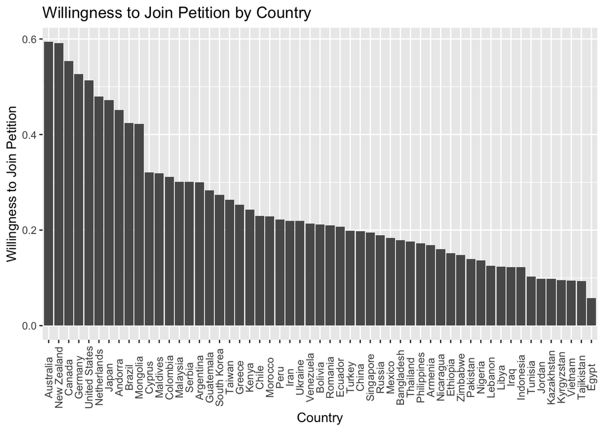

```r
petition_plot <- freedom |>
  ggplot(mapping = aes(x = fct_rev(fct_reorder(Country, petition)),
                       y = petition)) +
  geom_col() +
  theme(axis.text.x = element_text(angle = 90,
                                   vjust = 0.5,
                                   hjust = 0.5)) +
  labs(x = "Country",
       y = "Willingness to Join Petition",
       title = "Willingness to Join Petition by Country")
petition_plot
```

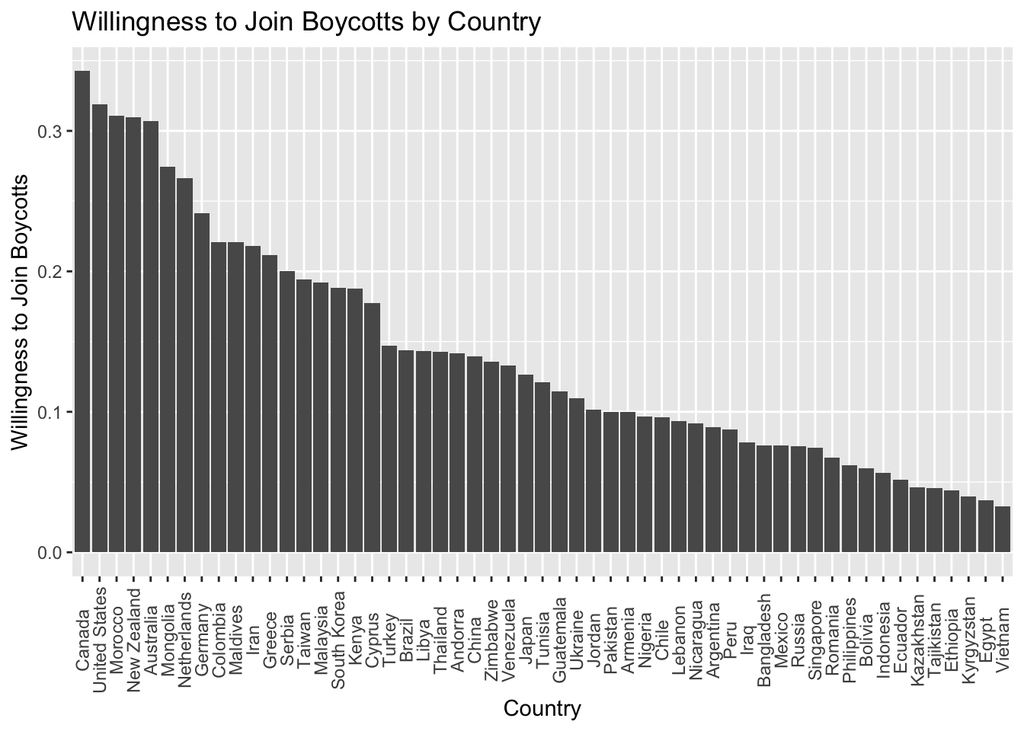

```r
boycotts_plot <- freedom |>
  ggplot(mapping = aes(x = fct_rev(fct_reorder(Country, boycotts)),
                       y = boycotts)) +
  geom_col() +
  theme(axis.text.x = element_text(angle = 90,
                                   vjust = 0.5,
                                   hjust = 0.5)) +
  labs(x = "Country",
       y = "Willingness to Join Boycotts",
       title = "Willingness to Join Boycotts by Country")
boycotts_plot
```

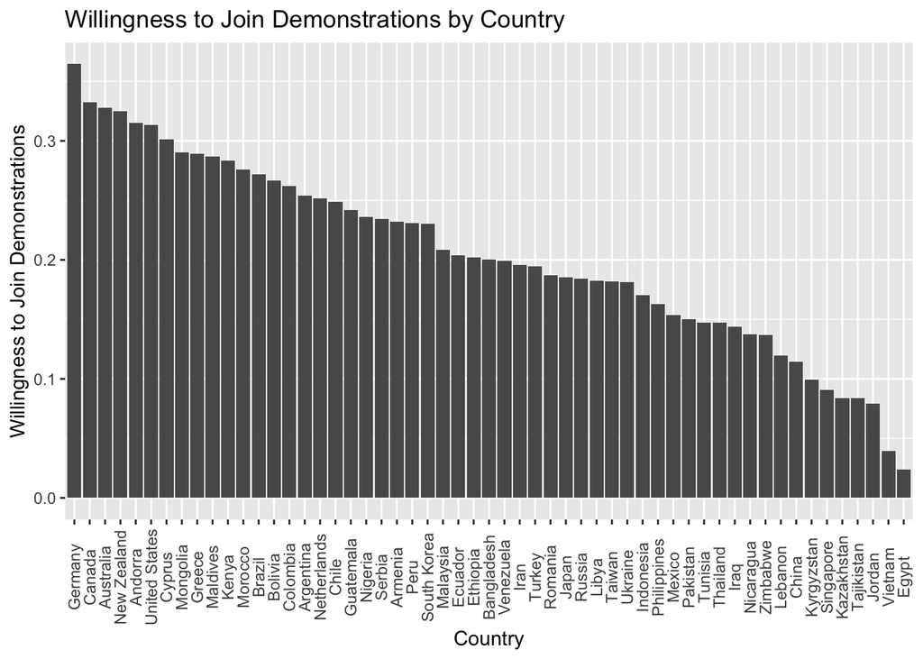

```r
demonstrations_plot <- freedom |>
  ggplot(mapping = aes(x = fct_rev(fct_reorder(Country, demonstrations)),
                       y = demonstrations)) +
  geom_col() +
  theme(axis.text.x = element_text(angle = 90,
                                   vjust = 0.5,
                                   hjust = 0.5)) +
  labs(x = "Country",
       y = "Willingness to Join Demonstrations",
       title = "Willingness to Join Demonstrations by Country")
demonstrations_plot
```

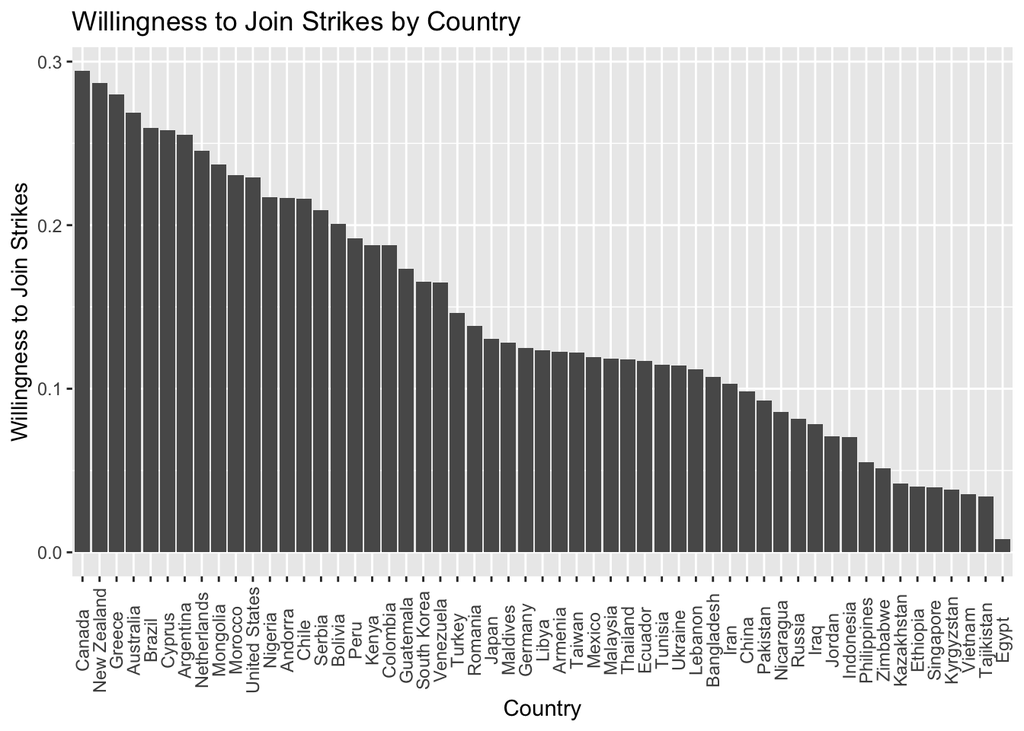

```r
strikes_plot <- freedom |>
  ggplot(mapping = aes(x = fct_rev(fct_reorder(Country, strikes)),
                       y = strikes)) +
  geom_col() +
  theme(axis.text.x = element_text(angle = 90,
                                   vjust = 0.5,
                                   hjust = 0.5)) +
  labs(x = "Country",
       y = "Willingness to Join Strikes",
       title = "Willingness to Join Strikes by Country")
strikes_plot
```

I also included several control variables including education, income, and political interest of the citizens, which are suspected to be significant confounding factors impacting the citizens’ political knowledge and enthusiasm in political participation. Both education and income are suspected to make people more aware of political issues and their significance, therefore more willing to participate in politics. A higher political interest is suspected to make poeple more aware of political issues and more exposed to media information regarding politics, therefore more influenced by it. People more interested in politics are also suspected to be overall more willing to participate politically than people who are less interested. The potential that these variables can affect the willingness of political participation is why they are included and controlled. These also come from World Values Survey (2017-2022 wave). All of these variables are self-reported by around 1000-4000 survey participants from each country in interviews with World Values Survey researchers (World Values Survey).

My key independent variable is the 2017 media freedom score for 55 countries around the globe from Freedom House. This score is a comprehensive measure considering legal (e.g. laws and constitutions), political (e.g. official and unofficial censorship), and economic (e.g. media-ownership) aspects of possible government control over media production in the real world, and I have rescaled it to range from 0 (least free) to 1 (most free) (Freedom House).

By comparing the media freedom scores from different countries and their respective citizens’ willingness to participate in petition, boycotts, demonstrations, and strikes, I am able to infer the effects media freedom has on citizens’ political participation. The following are scatterplots of raw relationships between media freedom and willingness to participate in each of the four political activities, with lines of best fit.

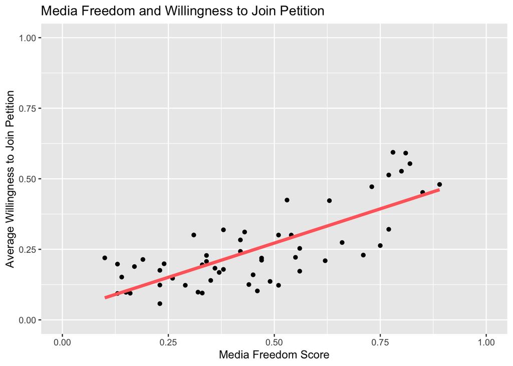

```r
media_petition <- freedom |>
  ggplot(mapping = aes(x = media_freedom_score,
         y = petition)) +
  geom_point() +
  geom_smooth(method = "lm", se = FALSE, color = "indianred1", size = 1.5) +
  coord_cartesian(xlim = c(0, 1), ylim = c(0, 1)) +
  labs(title = "Media Freedom and Willingness to Join Petition",
       x = "Media Freedom Score",
       y = "Average Willingness to Join Petition")
media_petition
```

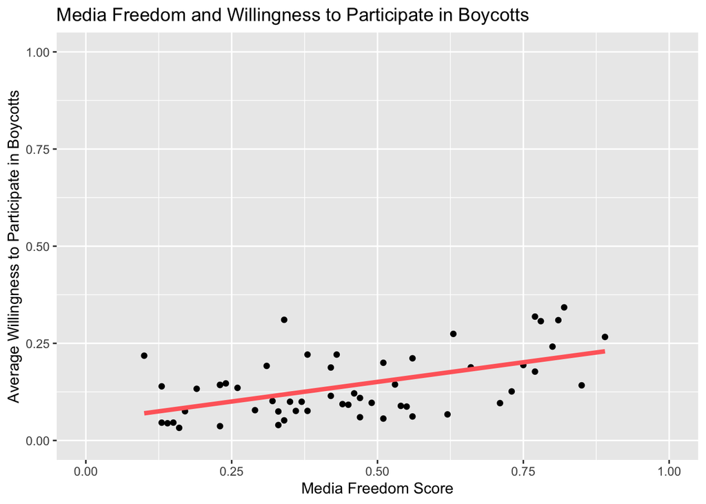

```r
media_boycotts <-freedom |>
  ggplot(mapping = aes(x = media_freedom_score,
         y = boycotts)) +
  geom_point() +
  geom_smooth(method = "lm", se = FALSE, color = "indianred1", size = 1.5) +
  coord_cartesian(xlim = c(0, 1), ylim = c(0, 1)) +
  labs(title = "Media Freedom and Willingness to Participate in Boycotts",
       x = "Media Freedom Score",
       y = "Average Willingness to Participate in Boycotts")
media_boycotts
```

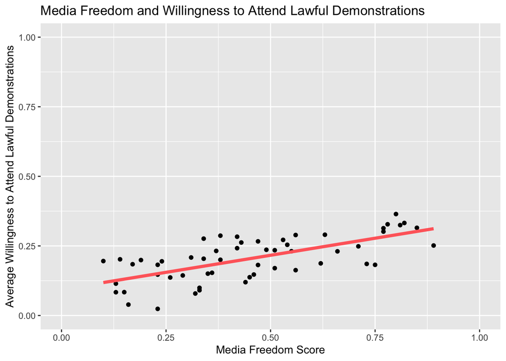

```r
media_demonstrations <- freedom |>
  ggplot(mapping = aes(x = media_freedom_score,
         y = demonstrations)) +
  geom_point() +
  geom_smooth(method = "lm", se = FALSE, color = "indianred1", size = 1.5) +
  coord_cartesian(xlim = c(0, 1), ylim = c(0, 1)) +
  labs(title = "Media Freedom and Willingness to Attend Lawful Demonstrations",
       x = "Media Freedom Score",
       y = "Average Willingness to Attend Lawful Demonstrations")
media_demonstrations
```

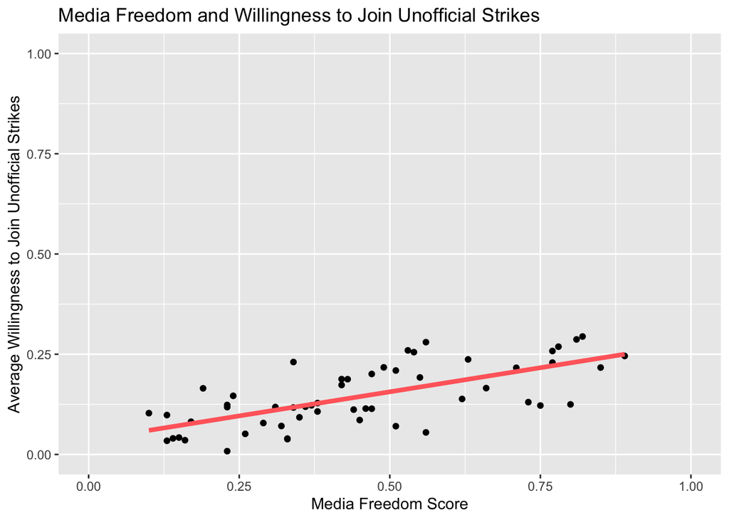

```r
media_strikes <- freedom |>
  ggplot(mapping = aes(x = media_freedom_score,
         y = strikes)) +
  geom_point() +
  geom_smooth(method = "lm", se = FALSE, color = "indianred1", size = 1.5) +
  coord_cartesian(xlim = c(0, 1), ylim = c(0, 1)) +
  labs(title = "Media Freedom and Willingness to Join Unofficial Strikes",
       x = "Media Freedom Score",
       y = "Average Willingness to Join Unofficial Strikes")
media_strikes
```

## Data Analysis

Multiple regression for petition:

```r
library(infer)
library(broom)
fit_petition <- lm(petition ~ media_freedom_score + education + income + political_interest, data = freedom)

library(broom)

var_labels <- c(
    "(Intercept)" = "Intercept",
    "media_freedom_score" = "Media Freedom Score",
    "education" = "Education",
    "income" = "Income",
    "political_interest" = "Political Interest"
)

modelsummary::modelsummary(fit_petition,
                             statistic = c("s.e. = {std.error}",
               "p = {p.value}"),
coef_map = var_labels,
gof_map = c("nobs", "r.squared", "adj.r.squared"))
```

|  | Model 1 |
| --- | --- |
| Intercept | -0.195 |
|  | s.e. = 0.108 |
|  | p = 0.077 |
| Media Freedom Score | 0.412 |
|  | s.e. = 0.058 |
|  | p = <0.001 |
| Education | 0.173 |
|  | s.e. = 0.114 |
|  | p = 0.134 |
| Income | 0.084 |
|  | s.e. = 0.220 |
|  | p = 0.705 |
| Political Interest | 0.431 |
|  | s.e. = 0.166 |
|  | p = 0.012 |
| Num.Obs. | 55 |
| R2 | 0.663 |
| R2 Adj. | 0.636 |

Multiple regression for boycotts:

```r
fit_boycotts <- lm(boycotts ~ media_freedom_score + education + income + political_interest, data = freedom)

library(broom)

var_labels <- c(
    "(Intercept)" = "Intercept",
    "media_freedom_score" = "Media Freedom Score",
    "education" = "Education",
    "income" = "Income",
    "political_interest" = "Political Interest"
)

modelsummary::modelsummary(fit_boycotts,
                             statistic = c("s.e. = {std.error}",
               "p = {p.value}"),
coef_map = var_labels,
gof_map = c("nobs", "r.squared", "adj.r.squared"))
```

|  | Model 1 |
| --- | --- |
| Intercept | -0.106 |
|  | s.e. = 0.086 |
|  | p = 0.228 |
| Media Freedom Score | 0.155 |
|  | s.e. = 0.046 |
|  | p = 0.002 |
| Education | 0.083 |
|  | s.e. = 0.091 |
|  | p = 0.365 |
| Income | 0.053 |
|  | s.e. = 0.177 |
|  | p = 0.767 |
| Political Interest | 0.351 |
|  | s.e. = 0.134 |
|  | p = 0.011 |
| Num.Obs. | 55 |
| R2 | 0.397 |
| R2 Adj. | 0.349 |

Multiple regression for demonstrations:

```r
fit_demonstrations <- lm(demonstrations ~ media_freedom_score + education + income + political_interest, data = freedom)

library(broom)

var_labels <- c(
    "(Intercept)" = "Intercept",
    "media_freedom_score" = "Media Freedom Score",
    "education" = "Education",
    "income" = "Income",
    "political_interest" = "Political Interest"
)

modelsummary::modelsummary(fit_demonstrations,
                             statistic = c("s.e. = {std.error}",
               "p = {p.value}"),
coef_map = var_labels,
gof_map = c("nobs", "r.squared", "adj.r.squared"))
```

|  | Model 1 |
| --- | --- |
| Intercept | 0.017 |
|  | s.e. = 0.076 |
|  | p = 0.829 |
| Media Freedom Score | 0.236 |
|  | s.e. = 0.041 |
|  | p = <0.001 |
| Education | -0.031 |
|  | s.e. = 0.081 |
|  | p = 0.700 |
| Income | 0.137 |
|  | s.e. = 0.156 |
|  | p = 0.386 |
| Political Interest | 0.088 |
|  | s.e. = 0.118 |
|  | p = 0.459 |
| Num.Obs. | 55 |
| R2 | 0.474 |
| R2 Adj. | 0.432 |

Multiple regression for strikes:

```r
fit_strikes <- lm(strikes ~ media_freedom_score + education + income + political_interest, data = freedom)

library(broom)

var_labels <- c(
    "(Intercept)" = "Intercept",
    "media_freedom_score" = "Media Freedom Score",
    "education" = "Education",
    "income" = "Income",
    "political_interest" = "Political Interest"
)

modelsummary::modelsummary(fit_strikes,
                             statistic = c("s.e. = {std.error}",
               "p = {p.value}"),
coef_map = var_labels,
gof_map = c("nobs", "r.squared", "adj.r.squared"))
```

[output not shown]

This estimated coefficient is of statistical significance for all four political activities, as the p-values are all consistently far below 0.05, being respectively <0.001, 0.002, <0.001, and <0.001. In this case, the null hypothesis of no relationship between media freedom and willingness to participate in political activities can be rejected. This means that the chance that this estimated coefficient is a result of chance and that there is actually no relationship between media freedom and willingness to participate in political activities is less than 5%.

In terms of causality, I don’t think this regression is sufficient enough to claim a causal conclusion between media freedom and political participation. While I did try to control confounders such as education, income, and political interest, there are also numerous other confounders such as polity, age, inequality, and geography that I have not taken into account because of restraints in the dataframe. Polity, for example, could be an omitted variable that explains both media freedom and political participation differences; in democracy, there could be higher media freedom, and simultaneously people could be more encouraged to participate in political affairs. To control for all or most confounding variables, I will have to merge data from multiple other sources, which for this project was not plausible in terms of time. Therefore, though I did control the confounding variables that I could think of using current sources, the possibility of numerous others make it difficult to draw a causal conclusion.

## Conclusion

In conclusion, media freedom by government control positively affects citizens’ willingness of political participation. The positive effects range from more than 15% to around 41% by changing one country’s media freedom from the least free to the most free, and these estimated effects are statistically significant. However, it is important to be mindful that this does not mean a causal relationship between the two due to the limitations of this study in controlling the numerous possible confounding variables such as polity, age, geography, inequality etc.. In this sense, if future research can control these variables, it would provide an opportunity to establish a causal relationship between media freedom and citizens’ political participation. Additionally, it would be beneficial if future studies can take an experimental approach to this topic and, if possible, do a natural experiment on two similar countries in a time frame of at least one or two decades (e.g. one country has a legal change increasing censorship, the other does not). This would not only help control confounders (by comparing two similar countries) but also provide a temporal perspective into the study of the relationship between media freedom and citizens’ political participation.

## Works Cited

Leeson, Peter T. “Media Freedom, Political Knowledge, and Participation.” Journal of Economic Perspectives, vol. 22, no. 2, 2008, pp. 155–169., https://doi.org/10.1257/jep.22.2.155.

“Media Freedom.” Freedom House, https://freedomhouse.org/issues/media-freedom.

“World Values Survey Association.” WVS Database, https://www.worldvaluessurvey.org/WVSDocumentationWV7.jsp.